El gancho

# 2010 y 2015

2 819 mm

de lluvia en 2010, contra 2 031 mm en 2015

- 2010: el año más húmedo, con 7 meses de La Niña
- 2015: el año más seco, con 12 meses de El Niño
- Julio de 2010: el mes más extremo de la serie (310 mm)

Gráfica del informe: «Los años contrastantes»

El año más húmedo, 2010, tuvo 7 meses de La Niña; el más seco, 2015, tuvo 12 meses de El Niño. Julio de 2010 fue el mes más extremo de toda la serie: 310 mm. Mismo río, mismos cerros. ¿Qué cambió?

La pregunta

# ¿Qué controla el caudal del Fonce en San Gil?

mes · año · 42 años

las tres escalas de la pregunta

- Tres escalas: de un mes a otro, de un año a otro y en 42 años
- Nuestra hipótesis: la lluvia controla el caudal, amortiguada por un almacenamiento de un mes
- Según nuestra hipótesis, la ETP no explica el caudal y El Niño actúa a través de la lluvia

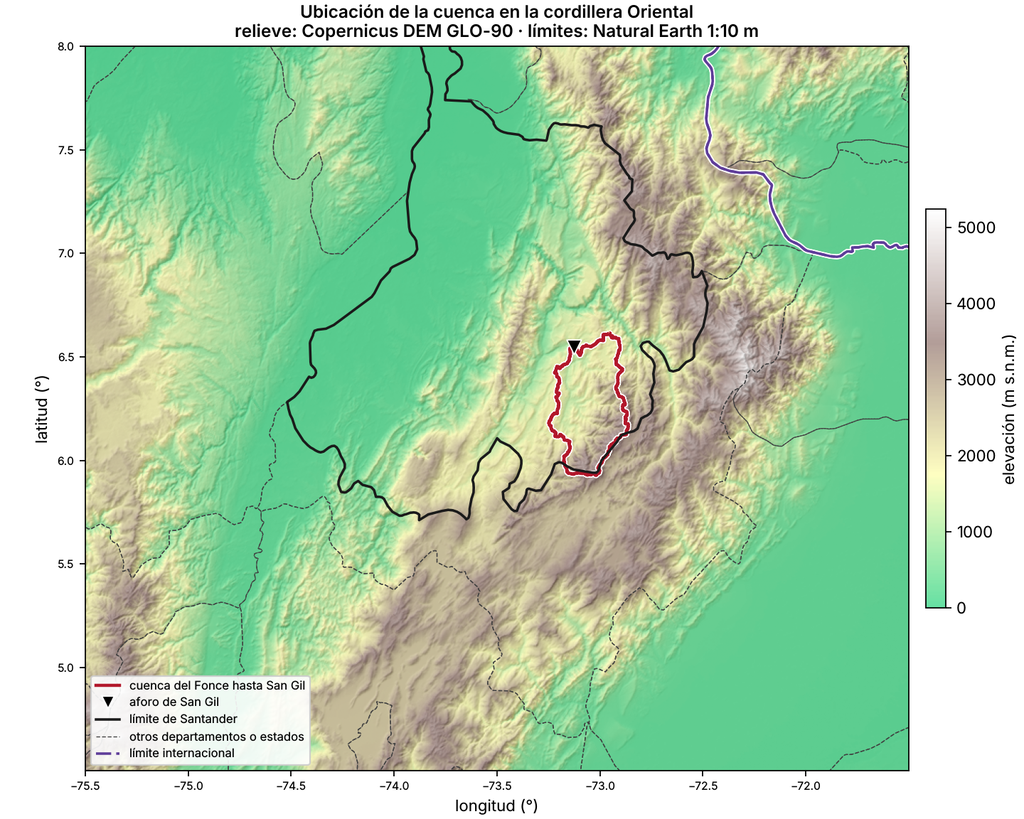

Gráfica del informe: Figura 1, «Contexto geográfico»

La pregunta tiene tres escalas: de un mes a otro, de un año a otro y en los 42 años desde 1981. Nuestra hipótesis: la lluvia controla el caudal, amortiguada por un almacenamiento de un mes; la evapotranspiración no explica nada; El Niño actúa a través de la lluvia.

La cuenca

# Una cuenca de montaña, medida dos veces

0

pluviómetros por encima de 2 625 m

- 2 099 km², de 1 114 a 4 297 m
- Lluvia del satélite IMERG (PI) y de 7 pluviómetros (PL), en paralelo
- PI queda 12 % por debajo de PL; manda PL, que sigue mejor al río

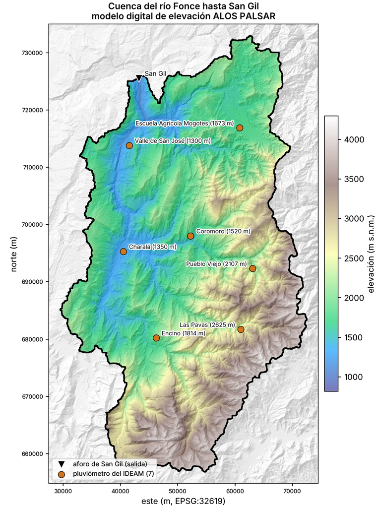

Gráfica del informe: Figura 2, «Mapas de la cuenca»

2 099 km², de 1 114 a 4 297 m. La lluvia se mide con el satélite IMERG (PI) y con 7 pluviómetros (PL), en paralelo. PI queda 12 % por debajo de PL. Arriba de 2 625 m, el 30 % de la cuenca, no hay pluviómetros. Cuando hay que escoger, manda PL, porque sigue mejor al río.

Conclusión 1

# Arriba llueve menos

−297 mm/año

por cada 1 000 m de altura (pluviómetros)

- El óptimo pluviográfico está en Encino, a 1 814 m
- El 63 % de la cuenca queda por encima del óptimo
- El aire que sube se enfría y le queda menos vapor que condensar

Gráfica del informe: «En esta cuenca llueve menos arriba»

Esperaríamos más lluvia arriba, y pasa lo contrario: por encima de Encino, a 1 814 m, cada estación mide menos. Es el óptimo pluviográfico. El aire húmedo sube por la ladera y se enfría; el aire frío contiene menos vapor, así que arriba queda poca agua que condensar. El 63 % de la cuenca está por encima del óptimo. (Si preguntan: Mesa et al. dan 1 500 m como cifra general; aquí sale más arriba, dentro del rango de 1 a 2 km de la AMS.)

Conclusión 2

# La lluvia llega en dos temporadas

25 de 25

años con los dos picos (PL)

- Picos de lluvia en abril y octubre; de caudal, en mayo y noviembre
- Causa: el doble paso de la ZCIT sobre el centro del país
- Diciembre a febrero es la temporada más seca: la cordillera Oriental frena la humedad (Hoyos et al., 2018)

Gráfica del informe: «El año típico: cuándo llueve y cuándo baja el río»

La Zona de Convergencia Intertropical pasa dos veces al año sobre el centro del país. Por eso hay dos picos de lluvia, abril y octubre, y dos de caudal, mayo y noviembre, todos los años. La temporada seca de diciembre a febrero es la más profunda: según Hoyos et al. (2018), la cordillera Oriental hace de barrera a la humedad que entra.

Conclusión 3

# El río tiene memoria

17 días

va el río detrás de la lluvia; el agua recorre el cauce en 4 a 10 horas

- El agua recorre el cauce en 4 a 10 horas, pero el río llega 17 días tarde
- La lluvia entra al suelo y al acuífero y sale después
- El 60 % del caudal es flujo base (BFI de 0.59)

Gráfica del informe: «Primero, en el año típico»

El agua tarda entre 4 y 10 horas en recorrer el cauce, pero el río va 17 días detrás de la lluvia. Esa diferencia no es el viaje por el río: es agua que se infiltra en el suelo y el acuífero y sale después. Miren la línea a trazos: con la lluvia del mes anterior, el modelo sigue al río. El 60 % del caudal es flujo base, la parte lenta que sostiene al río entre tormentas. En las temporadas secas el río vive de esa reserva.

Conclusión 4

# El ciclo lo pone la lluvia

P/ETP = 2

llueve el doble de lo que la atmósfera puede evaporar

- P/ETP anual de 2.01 con PL y 1.77 con PI: cuenca húmeda
- La ETP varía un 21 % en el año; la lluvia, un 97 %
- Sale por el río el 53 % de la lluvia (PL)

Gráfica del informe: «¿Húmeda o árida? La lluvia contra la ETP»

Es una cuenca húmeda: llueve el doble de la demanda de evaporación. Y en el trópico la energía casi no cambia en el año: la temperatura media varía 0.7 °C de un mes a otro. La demanda es casi pareja, así que lo que sube y baja el río es la lluvia. El 53 % de la lluvia sale por San Gil.

Conclusión 5 · el giro

# La evapotranspiración sí importa

+10 % ETP → −14 % Q

con la misma lluvia (M5, el modelo elegido)

- Nuestra hipótesis decía que la ETP no importaba: esa parte no se cumple
- Con PL, M5 baja el error de 24.6 a 21.2 mm/mes
- KGE de 0.78 con M4 y de 0.86 con M5
- La ETP de Hargreaves también refleja la nubosidad: no prueba el mecanismo

Gráfica del informe: «Seis modelos, de menos a más complejo» · se agregó M4 con PL, de las salidas del proyecto (out/modelos_estimados.csv)

Aquí nuestra hipótesis empezó a fallar. Decía que la ETP no explicaba nada; la pusimos a prueba: con la misma lluvia, un mes con 10 % más de ETP lleva 14 % menos caudal. Un mes con más demanda de la atmósfera evapora más y deja menos agua para el río. M5, lluvia más ETP, sube el KGE de 0.78 a 0.86. (Si preguntan: la ETP de Hargreaves también mide nubosidad; M5 no prueba el mecanismo.)

Conclusión 6

# El Niño seca la cuenca

r = −0.46

caudal contra el Pacífico (ONI, 1 mes antes); el Atlántico (TNA) llega a +0.36

- La gráfica compara el Pacífico (ONI, en negro) con el Atlántico (TNA, en azul): pesa mucho más el Pacífico, que explica el 21 % de la variación del caudal, contra el 13 %
- Con El Niño, el aire desciende sobre Colombia e inhibe la convección (Poveda, 2004)
- El Niño no mueve el río solo: lo hace a través de la lluvia de varios meses. La de un mes se relaciona poco con El Niño (−0.32), pero la de los últimos 6 meses llega a −0.56, tanto como el caudal

Gráfica del informe: «Q frente al ONI y al TNA»

Esta gráfica compara los dos océanos: la línea negra es el Pacífico (el ONI, El Niño) y las azules el Atlántico tropical norte (el TNA). El ONI pesa mucho más: explica el 21 % de la variación del caudal entre años, contra el 13 % del TNA, Parte de lo que se ve en el Atlántico viene del mismo El Niño. Si al TNA se le quita solo el ONI del mes anterior, no pasa la corrección; si se le quita el ONI de todo el año anterior, queda una relación de +0.29 con el TNA de 3 a 6 meses antes, que sí pasa. Así que un aporte propio del Atlántico es posible, pero depende de cómo se quite El Niño y no se puede afirmar con estos datos. De todo el clima global, lo único que resistió fue El Niño. Cuando el Pacífico ecuatorial se calienta, el aire sube sobre el océano y baja sobre Colombia, y ese descenso inhibe las nubes de tormenta. Además se debilitan los chorros que traen humedad y la ZCIT se corre al suroeste (Poveda, 2004). Llueve menos varios meses seguidos, y el río, que tiene memoria, lo acumula. Por eso la lluvia de un solo mes se relaciona poco con El Niño (−0.32), porque es ruidosa, pero si se promedia la de los últimos 6 meses la relación llega a −0.56, tanto como la del caudal: El Niño llega al río a través de la lluvia acumulada. Sin esa lluvia acumulada y sin la ETP, no queda relación.

Conclusión 7

# En 40 años sube la temperatura; el río no

+0.14 °C

por década; el caudal no tiene tendencia (p = 0.72)

- El calentamiento sube la ETP solo 0.5 % por década
- La lluvia no tiene tendencia significativa
- El caudal tampoco: −0.8 m³/s por década (p = 0.72)

Gráfica del informe: «Todos los datos: la secuencia de meses»

La temperatura sube 0.14 °C por década. Eso sube la ETP apenas 0.5 % por década, muy poco para mover el río. Como la lluvia no tiene tendencia, el caudal tampoco. Que no sea significativa no prueba que no haya cambio.

El desenlace

# Lluvia, memoria y El Niño

En parte

se cumple nuestra hipótesis: la ETP sí cuenta y falta un almacenamiento lento

- Se cumple: la lluvia del mes y la del anterior explican el caudal
- No se cumple: la ETP sí agrega información
- Hipótesis ajustada: lluvia menos ETP, con un almacenamiento rápido y otro lento

Gráfica del informe: «Lo que llueve menos lo que sale, contra la evapotranspiración»

La gráfica muestra lo que llueve menos lo que sale por el río (P − Q) contra la ETP. P − Q sube y baja mucho más que la ETP: en los meses de lluvia la cuenca guarda agua, y en 7 meses sale más agua de la que cae, que es el río drenando lo guardado. Ese es el almacenamiento. Volvamos a 2010 y 2015. En 2015, El Niño quitó lluvia mes tras mes, y un río con memoria lo fue acumulando. Nuestra hipótesis se sostiene en parte: la lluvia y la memoria explican el caudal, pero la ETP también cuenta y los residuos todavía siguen el calendario. Proponemos ajustarla: lluvia menos ETP, amortiguada por un almacenamiento rápido de un mes y otro más lento.

Lo que falta

# El Fonce no responde a la lluvia de hoy, sino a la de los últimos meses

30 %

de la cuenca, sobre 2 625 m, sin pluviómetro: arriba solo mide el satélite

- Una estación de lluvia en el páramo, sobre 2 625 m
- Un modelo con dos almacenamientos para probar la hipótesis ajustada
- El transporte de humedad con el IVT de ERA5

## Lo que explica la física

1. **Arriba llueve menos:** el aire húmedo se enfría al subir y descarga su vapor antes de los 1 814 m; más arriba queda poco que condensar
2. **Dos temporadas:** la ZCIT pasa dos veces al año sobre la cuenca: lluvia en abril y octubre, caudal en mayo y noviembre
3. **El río tiene memoria:** el agua se infiltra en el suelo y el acuífero y sale semanas después: el 59 % del caudal es flujo base
4. **El ciclo lo pone la lluvia:** en el trópico la energía casi no cambia en el año, así que la demanda de evaporación es casi pareja
5. **La ETP sí importa:** con más demanda de la atmósfera se evapora más y queda menos agua para el río
6. **El Niño seca la cuenca:** el aire desciende sobre Colombia e inhibe las nubes de tormenta; llueve menos varios meses y el río lo acumula
7. **Sube la temperatura, el río no:** la ETP sube apenas 0.5 % por década, y la lluvia, que es la que manda, no tiene tendencia

A la derecha, el resumen de lo que explica la física en cada conclusión. Lo que falta medir: una estación en el páramo, donde no hay pluviómetros; un modelo con dos almacenamientos para probar la hipótesis ajustada; y el transporte de humedad con el IVT de ERA5. Cierre: el Fonce no responde a la lluvia de hoy, sino a la de los últimos meses.

← → avanzar · N notas · F pantalla completa · pasa el cursor por las gráficas